# Machine Learning - Peer Assessments

Solange

August 18, 2015

## Executive summary

The goal of this project is to use data from accelerometers on the belt, forearm, arm, and dumbell of 6 participants and to predict “how well” (outcome: classe) they performed barbell lifts exercises. The data for this project come from this [source](http://groupware.les.inf.puc-rio.br/har) and all infromation about the variables can be found there.

The report contains 3 main parts: 1) pre-processing and exploratory data analysis, 2) prediction model building and out-of-error evaluation, 3) Conclusion.

## Pre-processing and exploratory data analysis

The training “pml-training.csv” and testing data contains “pml-testing.csv” contain 19622 and 20 observables for 160 variables respectively. First a pre-processing and an exploration of the data will be performed. All data frame manipulation done on the trainning set are also done on the testing set.

```r
setwd("D:/Mes_Documents/coursera/MachineLearning")
library(caret)
library(rattle)
# Read csv data
file_name <- "pml-training.csv"
trainingset<- read.csv(file_name, na.strings = c("NA", ""))

file_name <- "pml-testing.csv"
testingset<- read.csv(file_name, na.strings = c("NA", ""))

# Check that the two data sets have the same columns (except classe)
colnames(trainingset)[which(colnames(testingset) != colnames(trainingset))]
```

```
## [1] "classe"
```

```r
# Remove columns which have more than 60% of NA and row index column
sumNA <- apply(trainingset, 2, function(x) sum(is.na(x)))
trainingset_new <- trainingset[,which(sumNA < 0.6*dim(trainingset)[1])]
trainingset_new <- trainingset_new[, -grep("X", colnames(trainingset_new))]

testingset_new <- testingset[,which(sumNA < 0.6*dim(testingset)[1])]
testingset_new <- testingset_new[, -grep("X", colnames(testingset_new))]

# Extract relevant information from the timestamp
trainingset_new$date = strptime(trainingset_new$cvtd_timestamp, "%d/%m/%Y %H:%M")
testingset_new$date = strptime(testingset_new$cvtd_timestamp, "%d/%m/%Y %H:%M")

# add a variable to dataset called "weekday" that contains
# the day of the week that the measurement was done (0 = Sunday, 1 = Monday, etc.)
trainingset_new$weekday = trainingset_new$date$wday
testingset_new$weekday = testingset_new$date$wday

# add a variable to dataset called "day" that contains
# the day that the measurement was done
trainingset_new$day = trainingset_new$date$mday
testingset_new$day = testingset_new$date$mday

# add a variable to your datasets called "hour" that contains
# the hour that the measurement was done
trainingset_new$hour = trainingset_new$date$hour
testingset_new$hour = testingset_new$date$hour

# add a variable to your datasets called "minute" that contains
# the minutes that the measurement was done
trainingset_new$minute = trainingset_new$date$minute
testingset_new$minute = testingset_new$date$minute

# Remove now timestamp as we extract all information and date columns
trainingset_new <- trainingset_new[, -grep("timestamp", colnames(trainingset_new))]
trainingset_new <- trainingset_new[, -grep("date", colnames(trainingset_new))]

testingset_new <- testingset_new[, -grep("timestamp", colnames(testingset_new))]
testingset_new <- testingset_new[, -grep("date", colnames(testingset_new))]
```

The exploration plot below shows that there are no obvious linear relationship with the “total” variables and the outcome. Additionnaly, as the outcome is categorical with 5 levels, a calssification tree such as a CART or random forest model seem to be a reasonnable choice for this data set.

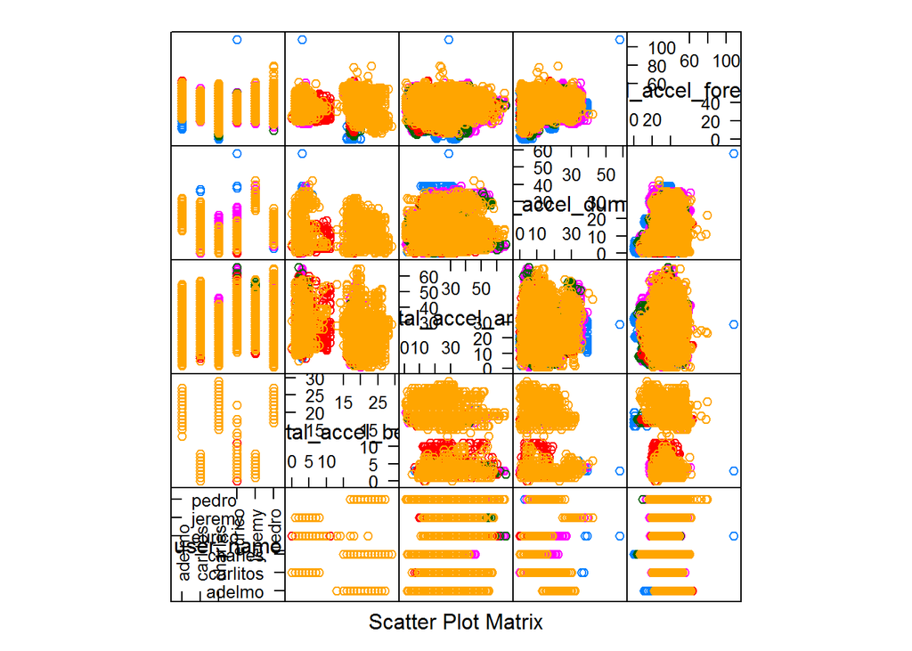

```r
# Only the total variables are plotted here
predictors_plot_index = grep("total",colnames(trainingset_new))
outcome_index = grep("classe",colnames(trainingset_new))

featurePlot(x=trainingset_new[,c(1, predictors_plot_index)], y= trainingset_new[,outcome_index], plot = "pairs")
```

## Prediction model building and out-of-error evaluation

First a CART model will be perfomed on the training data set to explore which features should be selected. CART model is chosen for its easy interpretation:

```r
modelFit <- train(classe ~ ., data = trainingset_new, method = "rpart")
```

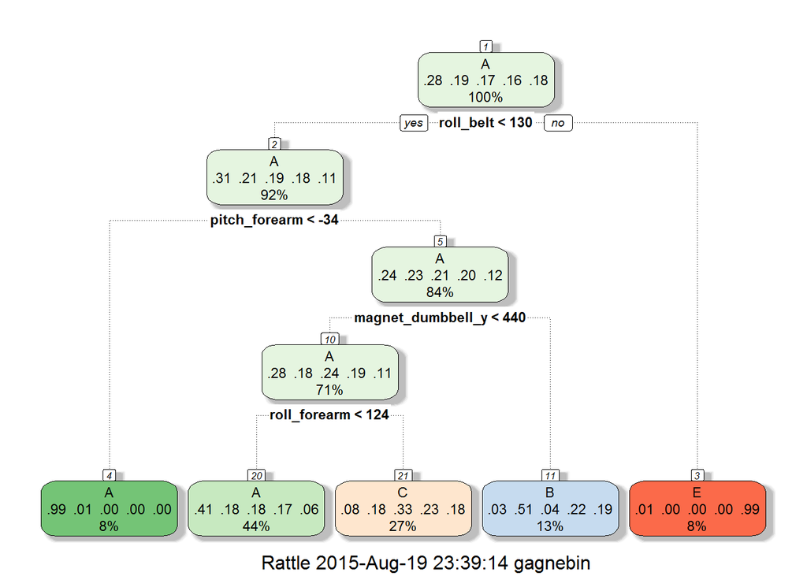

```r
fancyRpartPlot(modelFit$finalModel)
```

It seems that only four features are used in the model. Now a random forest algorithm will be trained using those four features. The default cross-validation will not be used, but instead a Repeated Cross-validation will be chosen to tune our model. That give more control on the cross-validation which highly used in random forest to avoid over-fitting:

```r
cvCtrl <- trainControl(method = "repeatedcv", number = 10, repeats = 5)

modelFit2 <- train(classe ~ pitch_forearm + roll_forearm + roll_belt + magnet_dumbbell_y
                  , data = trainingset_new, method = "rf", trControl = cvCtrl)
print(modelFit2$finalModel)
```

```
##
## Call:
##  randomForest(x = x, y = y, mtry = param$mtry)
##                Type of random forest: classification
##                      Number of trees: 500
## No. of variables tried at each split: 2
##
##         OOB estimate of  error rate: 7.93%
## Confusion matrix:
##      A    B    C    D    E class.error
## A 5259   49  192   74    6  0.05752688
## B   97 3183  287  195   35  0.16170661
## C   13   87 3155  144   23  0.07802455
## D   16   54  127 3009   10  0.06436567
## E   18   77   34   18 3460  0.04075409
```

The out-of-sample error will be estimate using the training set on the prediction:

```r
predtrain <- predict(modelFit2)
confusionMatrix(trainingset_new$classe, predtrain)
```

```
## Confusion Matrix and Statistics
##
##           Reference
## Prediction    A    B    C    D    E
##          A 5349    8  161   62    0
##          B   39 3477  176  105    0
##          C    0   52 3295   75    0
##          D   11   28   37 3140    0
##          E   13    7    5    2 3580
##
## Overall Statistics
##
##                Accuracy : 0.9602
##                  95% CI : (0.9574, 0.9629)
##     No Information Rate : 0.2758
##     P-Value [Acc > NIR] : < 2.2e-16
##
##                   Kappa : 0.9497
##  Mcnemar's Test P-Value : < 2.2e-16
##
## Statistics by Class:
##
##                      Class: A Class: B Class: C Class: D Class: E
## Sensitivity            0.9884   0.9734   0.8968   0.9279   1.0000
## Specificity            0.9837   0.9801   0.9920   0.9953   0.9983
## Pos Pred Value         0.9586   0.9157   0.9629   0.9764   0.9925
## Neg Pred Value         0.9955   0.9940   0.9766   0.9851   1.0000
## Prevalence             0.2758   0.1820   0.1872   0.1725   0.1824
## Detection Rate         0.2726   0.1772   0.1679   0.1600   0.1824
## Detection Prevalence   0.2844   0.1935   0.1744   0.1639   0.1838
## Balanced Accuracy      0.9861   0.9767   0.9444   0.9616   0.9992
```

```r
predtrain <- predict(modelFit2, testingset_new)

answers = as.character(predtrain)

pml_write_files = function(x){
  n = length(x)
  for(i in 1:n){
    filename = paste0("problem_id_",i,".txt")
    write.table(x[i],file=filename,quote=FALSE,row.names=FALSE,col.names=FALSE)
  }
}

pml_write_files(answers)
```

## Conclusion

Random forest (rf) was chosen as a final model for the following reason: 1. Accurate model 1. Robust again overfitting if cross-validation is used when growing trees

Unfortunately rf is really slow to run in particular when the number of trees and repetion in the cross-validation are high. The model could surely have been tuned more, but to avoid to have an overfitting problem no supplementary tuning was performed. Accoring to this model the testing set is expected to have 18 correct answers over 20 which correspond to 0.9 accuracy.

The data exploration should be more in depth to understand the relationship between the different features and the outcome, however for keeping this report as short as possible only a basic feature plot was presented.